# DV_TProject1

**Authors: Rolando Melendez, Hyunji Seo, Catherine Tu**

## Program file structure

00 Doc - contains .Rmd and .html

01 Data - contains the code to Extract, Transform, and Load our data

02 Tableau - this is where the Tableau workbook goes, make it a twb file

## Data summary and subset

```r
#Shows the subset and summary of the data frame
source("../01 Data/R_ExtractTransform.R", echo = TRUE)
```

```
##
## > require(dplyr)
```

```
##
## > setwd("C:\\Users\\hyunji\\Documents\\DataVisualization\\DV_TProject1\\01 Data\\CSVs")
##
## > file_path <- "bank-additional.csv"
##
## > df <- rename(read.csv(file_path, stringsAsFactors = FALSE,
## +     sep = ";"), dflt = default)
##
## > names(df) <- toupper(names(df))
##
## > names(df) <- gsub("\\.+", "_", names(df))
##
## > names(df)
##  [1] "AGE"            "JOB"            "MARITAL"        "EDUCATION"
##  [5] "DFLT"           "HOUSING"        "LOAN"           "CONTACT"
##  [9] "MONTH"          "DAY_OF_WEEK"    "DURATION"       "CAMPAIGN"
## [13] "PDAYS"          "PREVIOUS"       "POUTCOME"       "EMP_VAR_RATE"
## [17] "CONS_PRICE_IDX" "CONS_CONF_IDX"  "EURIBOR3M"      "NR_EMPLOYED"
## [21] "Y"
##
## > measures <- c("AGE", "DURATION", "CAMPAIGN", "PDAYS",
## +     "PREVIOUS", "EMP_VAR_RATE", "CONS_PRICE_IDX", "CONS_CONF_IDX",
## +     "EURIBOR3M", "NR_ ..." ... [TRUNCATED]
##
## > for (n in names(df)) {
## +     df[n] <- data.frame(lapply(df[n], gsub, pattern = "[^ -~]",
## +         replacement = ""))
## + }
##
## > dimensions <- setdiff(names(df), measures)
##
## > if (length(measures) > 1 || !is.na(dimensions)) {
## +     for (d in dimensions) {
## +         df[d] <- data.frame(lapply(df[d], gsub, pattern = "[\"']", ..." ... [TRUNCATED]
##
## > if (length(measures) > 1 || !is.na(measures)) {
## +     for (m in measures) {
## +         df[m] <- data.frame(lapply(df[m], gsub, pattern = "[^--.0-9]", .... [TRUNCATED]
##
## > write.csv(df, paste(gsub(".csv", "", file_path), ".reformatted.csv",
```

[output cut: 30 more lines]

```
##  MONTH varchar2(4000),
##  DAY_OF_WEEK varchar2(4000),
##  POUTCOME varchar2(4000),
##  Y varchar2(4000),
##  AGE number(38,4),
##  DURATION number(38,4),
##  CAMPAIGN number(38,4),
##  PDAYS number(38,4),
##  PREVIOUS number(38,4),
##  EMP_VAR_RATE number(38,4),
##  CONS_PRICE_IDX number(38,4),
##  CONS_CONF_IDX number(38,4),
##  EURIBOR3M number(38,4),
##  NR_EMPLOYED number(38,4)
##  );
```

```r
source("../01 Data/R_Load.R", echo = TRUE)
```

```
##
## > require("jsonlite")
```

```
##
## > require("RCurl")
```

```
##
## > df <- data.frame(fromJSON(getURL(URLencode("skipper.cs.utexas.edu:5001/rest/native/?query=\"select * from BNKMKTG\""),
## +     httpheader = c(DB = "j ..." ... [TRUNCATED]
##
## > head(df)
##          JOB  MARITAL        EDUCATION DFLT HOUSING LOAN   CONTACT MONTH
## 1 bluecollar  married          basic9y   no     yes   no  cellular   may
## 2      admin  married          unknown   no     yes   no telephone   apr
## 3   services  married       highschool   no     yes   no  cellular   apr
## 4 bluecollar divorced          basic6y   no     yes   no  cellular   may
## 5      admin   single universitydegree   no     yes   no  cellular   jul
## 6 technician divorced          unknown   no     yes  yes  cellular   oct
##   DAY_OF_WEEK    POUTCOME   Y AGE DURATION CAMPAIGN PDAYS PREVIOUS
## 1         wed nonexistent  no  37      204        2   999        0
## 2         wed     success yes  52      403        1     6        1
## 3         mon nonexistent  no  46      180        1   999        0
## 4         wed nonexistent  no  42       16        2   999        0
## 5         mon nonexistent  no  35      447        3   999        0
## 6         thu nonexistent  no  49       81        1   999        0
##   EMP_VAR_RATE CONS_PRICE_IDX CONS_CONF_IDX EURIBOR3M NR_EMPLOYED
## 1         -1.8         92.893         -46.2     1.334      5099.1
## 2         -1.8         93.749         -34.6     0.654      5008.7
## 3         -1.8         93.075         -47.1     1.405      5099.1
## 4         -1.8         92.893         -46.2     1.281      5099.1
## 5          1.4         93.918         -42.7     4.960      5228.1
## 6         -3.4         92.431         -26.9     0.754      5017.5
##
## > summary(df)
##          JOB           MARITAL                  EDUCATION
##  admin     :1012   divorced: 446   universitydegree  :1264
##  bluecollar: 884   married :2509   highschool        : 921
##  technician: 691   single  :1153   basic9y           : 574
##  services  : 393   unknown :  11   professionalcourse: 535
##  management: 324                   basic4y           : 429
##  retired   : 166                   basic6y           : 228
##  (Other)   : 649                   (Other)           : 168
##       DFLT         HOUSING          LOAN           CONTACT
##  no     :3315   no     :1839   no     :3349   cellular :2652
##  unknown: 803   unknown: 105   unknown: 105   telephone:1467
##  yes    :   1   yes    :2175   yes    : 665
```

[output cut: 21 more lines]

```
##  Min.   :-3.40000   Min.   :92.20   Min.   :-50.8   Min.   :0.635
##  1st Qu.:-1.80000   1st Qu.:93.08   1st Qu.:-42.7   1st Qu.:1.334
##  Median : 1.10000   Median :93.75   Median :-41.8   Median :4.857
##  Mean   : 0.08497   Mean   :93.58   Mean   :-40.5   Mean   :3.621
##  3rd Qu.: 1.40000   3rd Qu.:93.99   3rd Qu.:-36.4   3rd Qu.:4.961
##  Max.   : 1.40000   Max.   :94.77   Max.   :-26.9   Max.   :5.045
##
##   NR_EMPLOYED
##  Min.   :4964
##  1st Qu.:5099
##  Median :5191
##  Mean   :5166
##  3rd Qu.:5228
##  Max.   :5228
##
```

#### Explanation of Data:

This data relates to the direct marketing campaign of a Portuguese bank to have people subscribe to a term deposit at their institution. The campaign had gathered data regard their campaign efforts, individuals’ demographics, and external social situations at the time of the campaign.

## Scatter Plot

#### R Visualization

```
##
## > require(tidyr)
```

```
##
## > require(dplyr)
##
## > require(extrafont)
```

```
## Registering fonts with R
```

```
##
## > require(ggplot2)
```

```
##
## > dfs <- df %>% select(DURATION, Y, CONS_PRICE_IDX)
##
## > dfsY <- df %>% select(DURATION, Y, CONS_PRICE_IDX) %>%
## +     filter(Y == "yes")
##
## > dfsN <- df %>% select(DURATION, Y, CONS_PRICE_IDX) %>%
## +     filter(Y == "no")
##
## > ggplot() + coord_cartesian() + scale_x_continuous() +
## +     scale_y_continuous() + labs(title = "Portuguese Bank Marketing Campaign Effectiveness\n ..." ... [TRUNCATED]
```

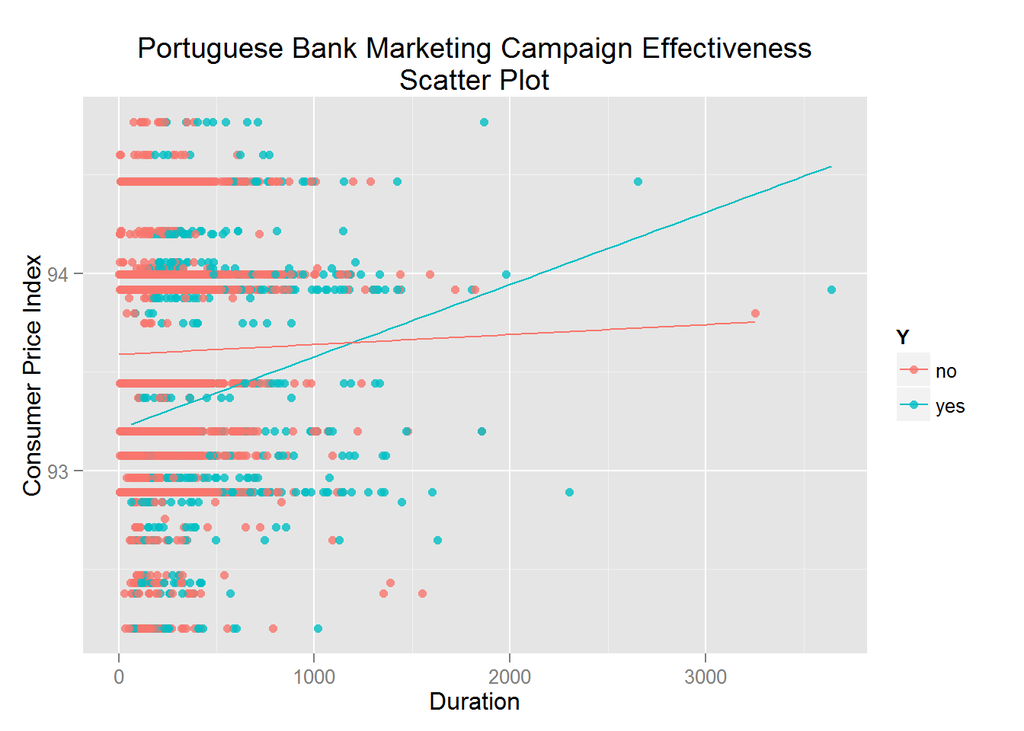

```r
#Shows the subset and summary of the data frame
source("../03 R SQL Visualizations/ScatterPlot.R", echo = TRUE)
```

#### Tableau Visualization

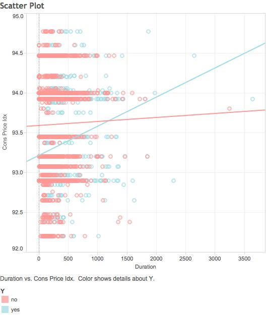

#### Findings:

In this visualization we observed Consumer Price Index (CONS.PRICE.IDX), duration of the last marketing call (DURATION), and final outcome of the campiagn (Y).

We found that for those who said yes there seemed to be a longer call duration and higher consumer price index for the period they were contacted. We speculate this is due to the fact that when consumer price index rises so do interest rates, and that would make people less likely to subscribe to a term deposit. Therefore, in order to get a yes, a longer call was required.

## Cross Tab and KPI

```r
#Shows the subset and summary of the data frame
source("../03 R SQL Visualizations/Crosstab_KPI.R", echo = TRUE)
```

```
##
## > require("jsonlite")
##
## > require("RCurl")
##
## > require(ggplot2)
##
## > require(dplyr)
##
## > KPI_Low_Max_value = 0.1
##
## > KPI_Medium_Max_value = 0.15
##
## > df %>% group_by(JOB) %>% summarize() %>% View()
##
## > dfc <- df %>% mutate(Yyes = ifelse(Y == "yes", 1,
## +     0), Yno = ifelse(Y == "no", 1, 0)) %>% group_by(EDUCATION) %>%
## +     mutate(Ratio = sum(Yy .... [TRUNCATED]
##
## > spread(dfc, Y, AVG_DURATION) %>% View
##
## > dfc$EDUCATION <- factor(dfc$EDUCATION, levels = c("illiterate",
## +     "basic4y", "basic6y", "basic9y", "highschool", "universitydegree",
## +     "pr ..." ... [TRUNCATED]
##
## > ggplot() + coord_cartesian() + scale_x_discrete() +
## +     scale_y_discrete() + scale_fill_manual(values = c("green",
## +     "yellow", "red")) + fac .... [TRUNCATED]
```

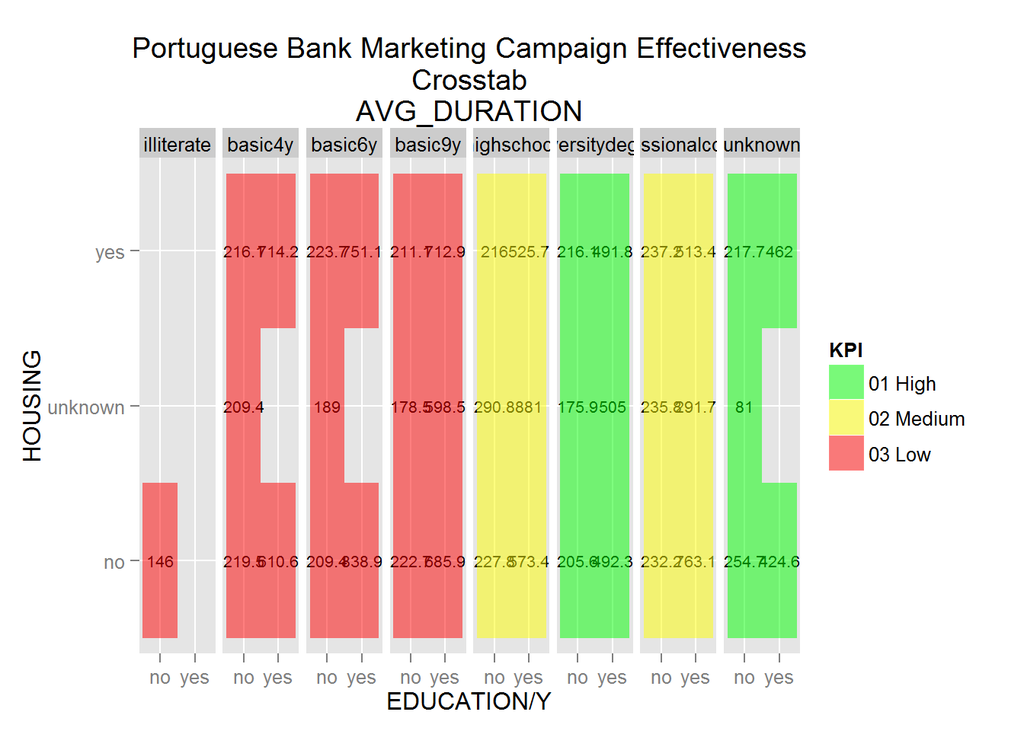

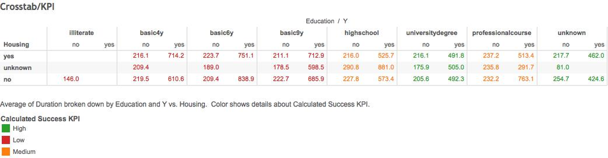

#### Findings:

For this graph, we compared the average call duration across target market groups sectioned by education level (Education) and whether or not they have a housing loan (Housing). We also further catgorized the market segment groups by a key performance indicator: the ratio of campaign successes to campaign failures in those of the same education level (Calculated Success KPI). Campaign success is defined as when they accepted a term deposit (Y) offer as a result of the campaign. A ‘High’ rating in the KPI indicated that the ratio of successes to failures exceeded 15%. A ‘Low’ rating indicated the ratio of successes to failures was less than 10%. This KPI rating also helps showcase which education level group the bank had more success in persuading.

We found that the bank generally found higher success rates when contacting people of higher education levels. It also seems that people of higher education levels also accepted the term deposit offer in a shorter call duration. Meanwhile, the bank had more difficulty persuading the market segments of elementary and junior high graduates. If the bank were to continue the campaign, we would suggest for them to spend more time and effort persuading those of higher education levels, as each second of a telemarketing call is more valuable in bringing these people to a decision.

## Bar Chart and Reference Line

#### R Visualization

```
##
## > require(tidyr)
##
## > require(dplyr)
##
## > require(extrafont)
##
## > require(ggplot2)
##
## > dfb <- df %>% group_by(POUTCOME, Y) %>% summarise(AVG_CAMPAIGN = mean(CAMPAIGN))
##
## > dfb1 <- dfb %>% ungroup %>% group_by(POUTCOME) %>%
## +     summarise(WINDOW_AVG_CAMPAIGN = mean(AVG_CAMPAIGN))
##
## > dfb <- inner_join(dfb, dfb1, by = "POUTCOME")
##
## > ggplot() + coord_cartesian() + scale_x_discrete() +
## +     scale_y_continuous() + facet_wrap(~POUTCOME, ncol = 1) +
## +     labs(title = "Portuguese  ..." ... [TRUNCATED]
```

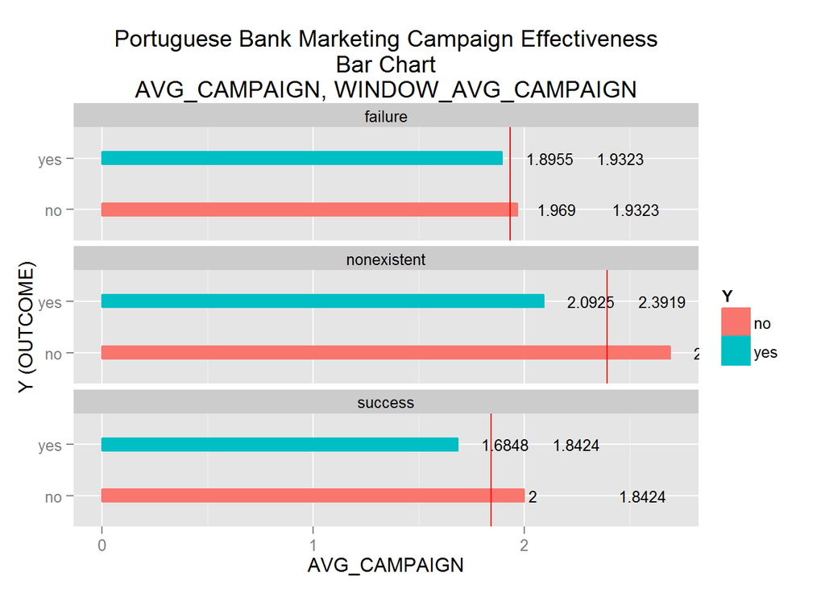

```r
#Shows the subset and summary of the data frame
source("../03 R SQL Visualizations/Barchart_RLine.R", echo = TRUE)
```

#### Tableau Visualization

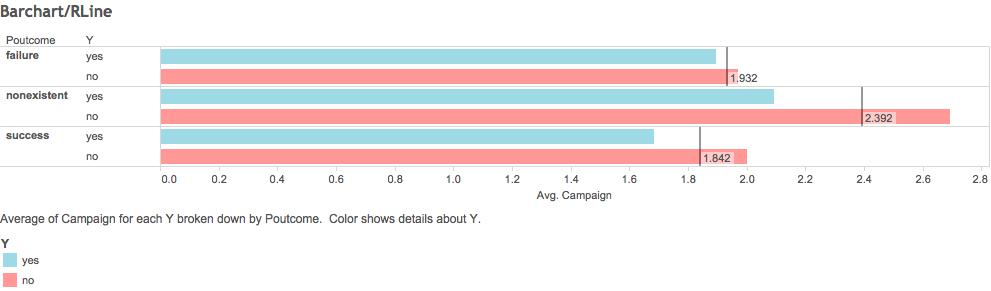

#### Findings:

In this visualization we observed the number of times each person was contacted in the current cmpaign (CAMPAIGN), past campaign outcome (POUTCOME), and current campaign outcome (Y)

Overall, we found that banks, on average, spent more effort on people who have not been contacted in previous campaigns. For those who have previously been a customer, banks required less contact times on average compared to the other two groups. This leaves previous non-customers who were contacted, on average, higher than previous customers, but lower than new targets. Lastly, one consistent trend was that across all groups the average effort needed to persuade those who ultimately said yes was less than those who refused.

## Data Blending

#### R Visualization

```r
#Shows the subset and summary of the data frame
source("../03 R SQL Visualizations/Blending.R", echo = TRUE)
```

```
##
## > require(tidyr)
##
## > require(dplyr)
##
## > require(extrafont)
##
## > require(ggplot2)
##
## > require(jsonlite)
##
## > require(RCurl)
##
## > dfbl <- data.frame(fromJSON(getURL(URLencode(gsub("\n",
## +     " ", "skipper.cs.utexas.edu:5001/rest/native/?query=\n        \"\"\"select JOB_TYPE a .... [TRUNCATED]
##
## > ndfbl <- spread(dfbl, MEASURE_NAMES, MEASURE_VALUES) %>%
## +     arrange(desc(AVERAGE_SALARY))
##
## > ndfbl$ORDERED_JOBS <- reorder(ndfbl$JOB_NAME, ndfbl$AVERAGE_SALARY)
##
## > ggplot() + coord_cartesian() + scale_x_discrete() +
## +     scale_y_continuous(limits = c(0, 1e+05)) + scale_fill_gradient(low = "grey90",
## +     hig .... [TRUNCATED]
```

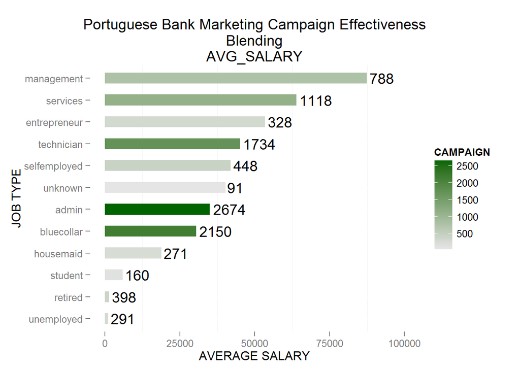

#### Tableau Visualization

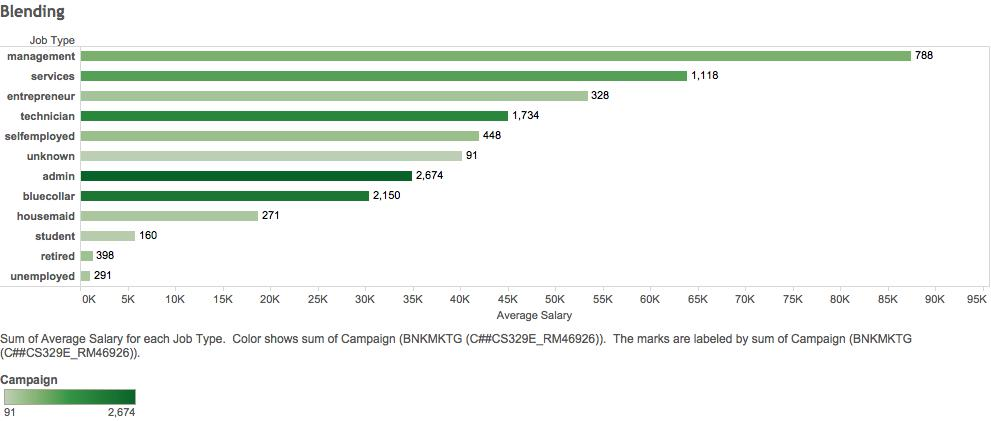

#### Findings:

For this visualization, we blended two data sets - job-type and bank-additional - and extracted the relationship between the variables JOB TYPE, CAMPAIGN, and AVERAGE SALARY. We used JOB TYPE as the common variable between the two data sets, and created a relationship in Tableau through JOB TYPE. The CAMPAIGN variable represented the number of contacts performed during the current marketing campaign for a specific client, while the AVERAGE SALARY represented the annual salary of clients, given by job types.

In Tableau, we placed AVERAGE SALARY into columns and JOB TYPE into rows, and illustrated the relationship through a bar graph. Then, we incorporated CAMPAIGN as an aggregated SUM value, marked through color and label. For ease, we sorted the job type by descending salary, rather than alphabetically.